# SOLLU PAVAN_IIT-MADRAS_2

Pavan

13/06/2020

```r
# Load libraries
library(tidyverse)
library(arules)
```

```r
library(arulesViz)
library(knitr)
library(gridExtra)
library(lubridate)
data = read_csv("C:/Users/pavan/Downloads/transaction_data.csv")
summary(data)
```

```
##      UserId       TransactionId     TransactionTime       ItemCode
##  Min.   :    -1   Min.   :5900015   Length:1083818     Min.   :     -1
##  1st Qu.:259392   1st Qu.:6026856   Class :character   1st Qu.: 460908
##  Median :302022   Median :6166611   Mode  :character   Median : 475293
##  Mean   :241016   Mean   :6159417                      Mean   : 658269
##  3rd Qu.:341355   3rd Qu.:6289569                      3rd Qu.: 488943
##  Max.   :384027   Max.   :6397457                      Max.   :1894494
##  ItemDescription    NumberOfItemsPurchased  CostPerItem
##  Length:1083818     Min.   :-242985.00     Min.   : -15265.6
##  Class :character   1st Qu.:      3.00     1st Qu.:      1.7
##  Mode  :character   Median :      9.00     Median :      2.9
##                     Mean   :     28.66     Mean   :      9.5
##                     3rd Qu.:     30.00     3rd Qu.:      5.7
##                     Max.   : 242985.00     Max.   :1696285.4
##    Country
##  Length:1083818
##  Class :character
##  Mode  :character
##
##
##
```

The negative values in ‘userId’ and ‘ItemCode’ is the missing data where as the negative values in ‘NumberofItemsPurchased’ and ‘CostperItem’ are because of cancelled or refunded values.  
We will perform some cleaning in data.

```r
glimpse(data)
```

```
## Rows: 1,083,818
## Columns: 8
## $ UserId                 <dbl> 278166, 337701, 267099, 380478, -1, 285957, ...
## $ TransactionId          <dbl> 6355745, 6283376, 6385599, 6044973, 6143225,...
## $ TransactionTime        <chr> "Sat Feb 02 12:50:00 IST 2019", "Wed Dec 26 ...
## $ ItemCode               <dbl> 465549, 482370, 490728, 459186, 1733592, 178...
## $ ItemDescription        <chr> "FAMILY ALBUM WHITE PICTURE FRAME", "LONDON ...
## $ NumberOfItemsPurchased <dbl> 6, 3, 72, 3, 3, 12, 9, 120, 36, 36, 36, 3, 3...
## $ CostPerItem            <dbl> 11.73, 3.52, 0.90, 1.73, 3.40, 3.52, 6.84, 1...
## $ Country                <chr> "United Kingdom", "United Kingdom", "France"...
```

```r
dim(data)
```

```
## [1] 1083818       8
```

```r
head(data)
```

```
## # A tibble: 6 x 8
##   UserId TransactionId TransactionTime ItemCode ItemDescription NumberOfItemsPu~
##    <dbl>         <dbl> <chr>              <dbl> <chr>                      <dbl>
## 1 278166       6355745 Sat Feb 02 12:~   465549 FAMILY ALBUM W~                6
## 2 337701       6283376 Wed Dec 26 09:~   482370 LONDON BUS COF~                3
## 3 267099       6385599 Fri Feb 15 09:~   490728 SET 12 COLOUR ~               72
## 4 380478       6044973 Fri Jun 22 07:~   459186 UNION JACK FLA~                3
## 5     -1       6143225 Mon Sep 10 11:~  1733592 WASHROOM METAL~                3
## 6 285957       6307136 Fri Jan 11 09:~  1787247 CUT GLASS T-LI~               12
## # ... with 2 more variables: CostPerItem <dbl>, Country <chr>
```

```r
data$UserId[data$UserId < 0] = NA # cleaning the negative data
data$ItemCode[data$ItemCode < 0] = NA
```

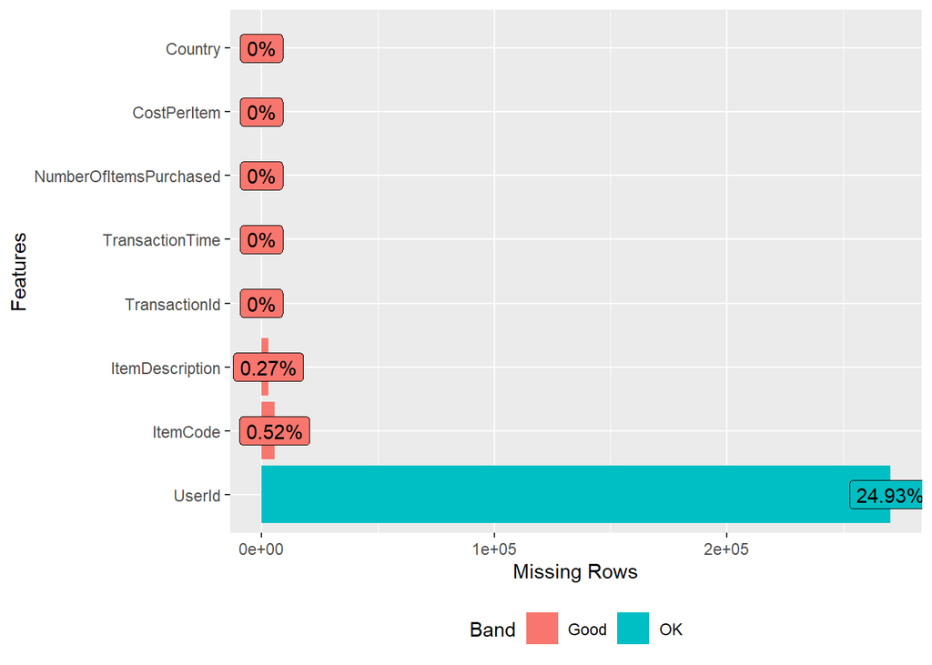

```r
library(DataExplorer)
options(repr.plot.width=8, repr.plot.height=8)
plot_missing(data)
```

We can see that except ‘user_id’ all the remaining features have almost all data available.

We know ‘user_id’ is not an important feature to predict the ‘items of basket’ so instead of omiting with respect to ‘user_id’ we will go with other features, so that we can perform further analysis on almost full data set.

```r
data$UserId = NULL
dim(data)
```

```
## [1] 1083818       7
```

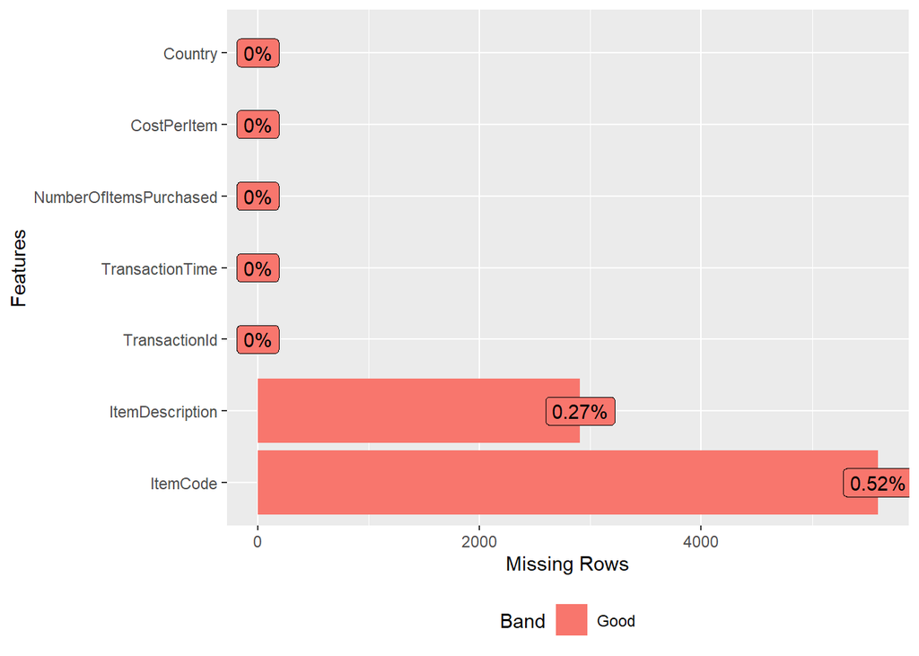

```r
options(repr.plot.width=8, repr.plot.height=8)
plot_missing(data)
```

As this missing data is very small compared to data set, thus we can omit this missing row’s and continue our analysis on remaining data.

```r
data = na.omit(data)
dim(data)
```

```
## [1] 1075328       7
```

```r
summary(data)
```

```
##  TransactionId     TransactionTime       ItemCode       ItemDescription
##  Min.   :5900015   Length:1075328     Min.   :     42   Length:1075328
##  1st Qu.:6026933   Class :character   1st Qu.: 461517   Class :character
##  Median :6167612   Mode  :character   Median : 475419   Mode  :character
##  Mean   :6159656                      Mean   : 660933
##  3rd Qu.:6290207                      3rd Qu.: 488964
##  Max.   :6397457                      Max.   :1894494
##  NumberOfItemsPurchased  CostPerItem          Country
##  Min.   :-242985.00     Min.   :      0.0   Length:1075328
##  1st Qu.:      3.00     1st Qu.:      1.7   Class :character
##  Median :      9.00     Median :      2.9   Mode  :character
##  Mean   :     28.93     Mean   :      7.7
##  3rd Qu.:     30.00     3rd Qu.:      5.7
##  Max.   : 242985.00     Max.   :1696285.4
```

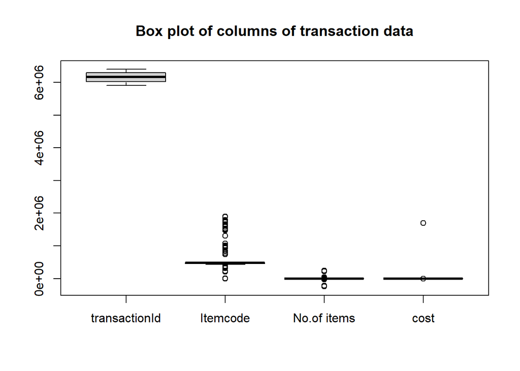

```r
boxplot(data$TransactionId,data$ItemCode,data$NumberOfItemsPurchased,data$CostPerItem,names = c("transactionId","Itemcode","No.of items","cost"),main = "Box plot of columns of transaction data")
```

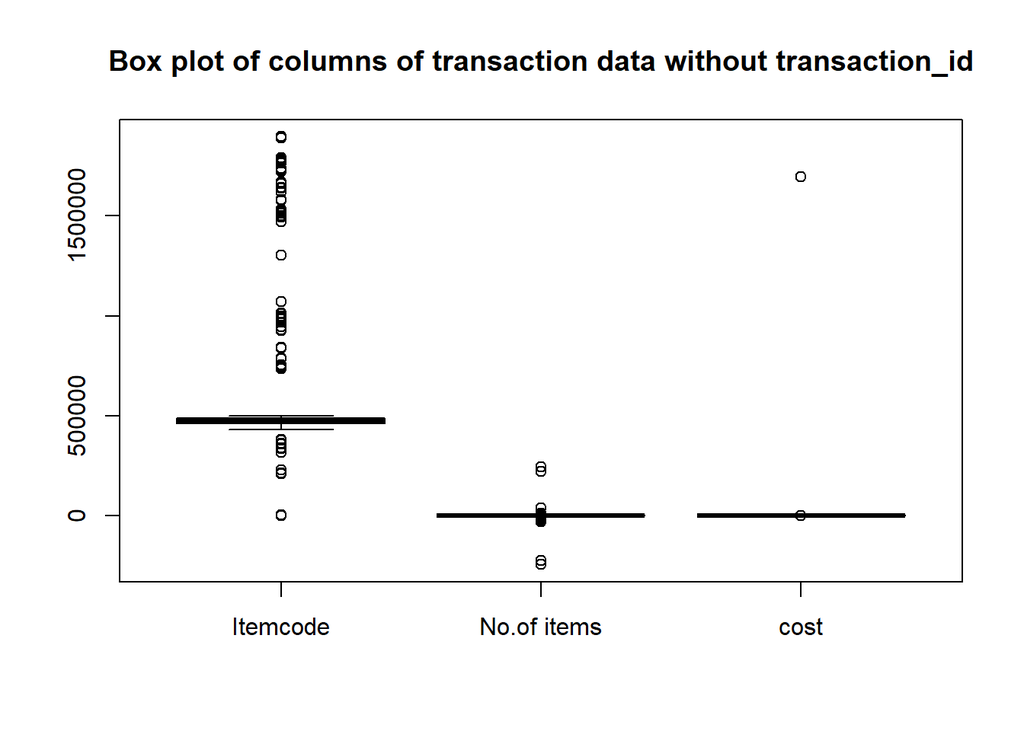

```r
boxplot(data$ItemCode,data$NumberOfItemsPurchased,data$CostPerItem,names = c("Itemcode","No.of items","cost"),main = "Box plot of columns of transaction data without transaction_id")
```

```r
# Extracting date,time,month,day,year and adding as new columns for EDA

data$day <- sapply(data$TransactionTime, FUN = function(x) {strsplit(x, split = '[ ]')[[1]][1]})
data$month <- sapply(data$TransactionTime, FUN = function(x) {strsplit(x, split = '[ ]')[[1]][2]})
data$date <- sapply(data$TransactionTime, FUN = function(x) {strsplit(x, split = '[ ]')[[1]][3]})
data$time <- sapply(data$TransactionTime, FUN = function(x) {strsplit(x, split = '[ ]')[[1]][4]})
data$year <- sapply(data$TransactionTime, FUN = function(x) {strsplit(x, split = '[ ]')[[1]][6]})
dim(data)
```

```
## [1] 1075328      12
```

```r
head(data)
```

```
## # A tibble: 6 x 12
##   TransactionId TransactionTime ItemCode ItemDescription NumberOfItemsPu~
##           <dbl> <chr>              <dbl> <chr>                      <dbl>
## 1       6355745 Sat Feb 02 12:~   465549 FAMILY ALBUM W~                6
## 2       6283376 Wed Dec 26 09:~   482370 LONDON BUS COF~                3
## 3       6385599 Fri Feb 15 09:~   490728 SET 12 COLOUR ~               72
## 4       6044973 Fri Jun 22 07:~   459186 UNION JACK FLA~                3
## 5       6143225 Mon Sep 10 11:~  1733592 WASHROOM METAL~                3
## 6       6307136 Fri Jan 11 09:~  1787247 CUT GLASS T-LI~               12
## # ... with 7 more variables: CostPerItem <dbl>, Country <chr>, day <chr>,
## #   month <chr>, date <chr>, time <chr>, year <chr>
```

```r
data$TransactionTime = NULL
dim(data)
```

```
## [1] 1075328      11
```

```r
data$hour <- sapply(data$time, FUN = function(x) {strsplit(x, split = '[:]')[[1]][1]})
```

```r
summary(data)
```

```
##  TransactionId        ItemCode       ItemDescription    NumberOfItemsPurchased
##  Min.   :5900015   Min.   :     42   Length:1075328     Min.   :-242985.00
##  1st Qu.:6026933   1st Qu.: 461517   Class :character   1st Qu.:      3.00
##  Median :6167612   Median : 475419   Mode  :character   Median :      9.00
##  Mean   :6159656   Mean   : 660933                      Mean   :     28.93
##  3rd Qu.:6290207   3rd Qu.: 488964                      3rd Qu.:     30.00
##  Max.   :6397457   Max.   :1894494                      Max.   : 242985.00
##   CostPerItem          Country              day               month
##  Min.   :      0.0   Length:1075328     Length:1075328     Length:1075328
##  1st Qu.:      1.7   Class :character   Class :character   Class :character
##  Median :      2.9   Mode  :character   Mode  :character   Mode  :character
##  Mean   :      7.7
##  3rd Qu.:      5.7
##  Max.   :1696285.4
##      date               time               year               hour
##  Length:1075328     Length:1075328     Length:1075328     Length:1075328
##  Class :character   Class :character   Class :character   Class :character
##  Mode  :character   Mode  :character   Mode  :character   Mode  :character
##
##
##
```

Now type caste the date,year and hour to numeric for further analysis

```r
data$date = as.numeric(data$date)# type casting char to numeric
data$year = as.numeric(data$year)
data$hour = as.numeric(data$hour)
summary(data)
```

```
##  TransactionId        ItemCode       ItemDescription    NumberOfItemsPurchased
##  Min.   :5900015   Min.   :     42   Length:1075328     Min.   :-242985.00
##  1st Qu.:6026933   1st Qu.: 461517   Class :character   1st Qu.:      3.00
##  Median :6167612   Median : 475419   Mode  :character   Median :      9.00
##  Mean   :6159656   Mean   : 660933                      Mean   :     28.93
##  3rd Qu.:6290207   3rd Qu.: 488964                      3rd Qu.:     30.00
##  Max.   :6397457   Max.   :1894494                      Max.   : 242985.00
##   CostPerItem          Country              day               month
##  Min.   :      0.0   Length:1075328     Length:1075328     Length:1075328
##  1st Qu.:      1.7   Class :character   Class :character   Class :character
##  Median :      2.9   Mode  :character   Mode  :character   Mode  :character
##  Mean   :      7.7
##  3rd Qu.:      5.7
##  Max.   :1696285.4
##       date           time                year           hour
##  Min.   : 1.00   Length:1075328     Min.   :2018   Min.   : 2.000
##  1st Qu.: 9.00   Class :character   1st Qu.:2018   1st Qu.: 7.000
##  Median :17.00   Mode  :character   Median :2018   Median : 9.000
##  Mean   :16.02                      Mean   :2018   Mean   : 9.079
##  3rd Qu.:23.00                      3rd Qu.:2019   3rd Qu.:11.000
##  Max.   :31.00                      Max.   :2028   Max.   :16.000
```

We can see from the above summary that the year has max value as 2028 but the data set is for year’s 2018 and 2019 thus it is recognised as typing error and let’s change 2028 to 2018.  
All the remaining features has in range values thus no cleaning is required for them.

```r
data$year[data$year == 2028] = 2018
summary(data$year)
```

```
##    Min. 1st Qu.  Median    Mean 3rd Qu.    Max.
##    2018    2018    2018    2018    2018    2019
```

```r
data$bill = data$NumberOfItemsPurchased * data$CostPerItem # Extracting revenue for
head(data)                                                # revenue analysis
```

```
## # A tibble: 6 x 13
##   TransactionId ItemCode ItemDescription NumberOfItemsPu~ CostPerItem Country
##           <dbl>    <dbl> <chr>                      <dbl>       <dbl> <chr>
## 1       6355745   465549 FAMILY ALBUM W~                6       11.7  United~
## 2       6283376   482370 LONDON BUS COF~                3        3.52 United~
## 3       6385599   490728 SET 12 COLOUR ~               72        0.9  France
## 4       6044973   459186 UNION JACK FLA~                3        1.73 United~
## 5       6143225  1733592 WASHROOM METAL~                3        3.4  United~
## 6       6307136  1787247 CUT GLASS T-LI~               12        3.52 United~
## # ... with 7 more variables: day <chr>, month <chr>, date <dbl>, time <chr>,
## #   year <dbl>, hour <dbl>, bill <dbl>
```

```r
summary(data$bill)
```

```
##     Min.  1st Qu.   Median     Mean  3rd Qu.     Max.
##  -699797       15       40      151       72 40710851
```

The negative value in ‘bill’ are because of order cancellation.

```r
data$Country = as.factor(data$Country) # Extracting levels of data
data$month = as.factor(data$month)
data$year = as.factor(data$year)
levels(data$year) = c(2018,2019)
data$hour = as.factor(data$hour)
data$day = as.factor(data$day)
levels(data$month)
```

```
##  [1] "Apr" "Aug" "Dec" "Feb" "Jan" "Jul" "Jun" "Mar" "May" "Nov" "Oct" "Sep"
```

```r
levels(data$Country)
```

```
##  [1] "Australia"            "Austria"              "Bahrain"
##  [4] "Belgium"              "Brazil"               "Canada"
##  [7] "Channel Islands"      "Cyprus"               "Czech Republic"
## [10] "Denmark"              "EIRE"                 "European Community"
## [13] "Finland"              "France"               "Germany"
## [16] "Greece"               "Hong Kong"            "Iceland"
## [19] "Israel"               "Italy"                "Japan"
## [22] "Lebanon"              "Lithuania"            "Malta"
## [25] "Netherlands"          "Norway"               "Poland"
## [28] "Portugal"             "RSA"                  "Saudi Arabia"
## [31] "Singapore"            "Spain"                "Sweden"
## [34] "Switzerland"          "United Arab Emirates" "United Kingdom"
## [37] "Unspecified"          "USA"
```

```r
levels(data$day)
```

```
## [1] "Fri" "Mon" "Sat" "Sun" "Tue" "Wed"
```

From above we can conclude that all the data is clear without any errors.

```r
country_Summary = data %>%
  group_by(Country) %>%
  summarise(Number_of_Orders=n(),revenue = sum(bill), transactions = n_distinct(TransactionId)) %>%
  ungroup() %>%
  arrange(desc(revenue))
head(country_Summary)
```

```
## # A tibble: 6 x 4
##   Country        Number_of_Orders    revenue transactions
##   <fct>                     <int>      <dbl>        <int>
## 1 United Kingdom           984882 150307940.        21585
## 2 Netherlands                4660   2353621.           97
## 3 EIRE                      16366   2197240.          349
## 4 Germany                   18192   1666216.          578
## 5 France                    16472   1513181.          442
## 6 Australia                  2514   1136883.           67
```

```r
unique(country_Summary$Country)
```

```
##  [1] United Kingdom       Netherlands          EIRE
##  [4] Germany              France               Australia
##  [7] Switzerland          Spain                Belgium
## [10] Japan                Sweden               Norway
## [13] Portugal             Channel Islands      Finland
## [16] Denmark              Italy                Cyprus
## [19] Hong Kong            Singapore            Austria
## [22] Israel               Poland               Unspecified
## [25] Greece               Iceland              Canada
## [28] Malta                United Arab Emirates USA
## [31] Lebanon              Lithuania            European Community
## [34] Brazil               RSA                  Czech Republic
## [37] Bahrain              Saudi Arabia
## 38 Levels: Australia Austria Bahrain Belgium Brazil Canada ... USA
```

As ‘UK’ values are more dominating we can pridict that it can be a ‘UK’ based company.

Let’s visualise the remaining top countries.

```r
top_Countries <- data %>%
  filter(Country == 'Netherlands'| Country == 'EIRE' | Country == 'Germany' | Country == 'France' | Country == 'Australia')

top_Country_Summary <- top_Countries %>%
  group_by(Country, month) %>%
  summarise(revenue = sum(bill), transactions = n_distinct(TransactionId))%>%
  ungroup() %>%
  arrange(desc(revenue))
head(top_Country_Summary)
```

```
## # A tibble: 6 x 4
##   Country     month revenue transactions
##   <fct>       <fct>   <dbl>        <int>
## 1 Netherlands Jan   445720.           17
## 2 EIRE        Dec   285480.           54
## 3 EIRE        Oct   284262            31
## 4 Netherlands Oct   269797.            5
## 5 Germany     Dec   260808.           75
## 6 France      Jan   246914.           59
```

```r
summary(top_Country_Summary)
```

```
##         Country       month       revenue        transactions
##  Australia  :12   Apr    : 5   Min.   :  5760   Min.   : 3.00
##  EIRE       :12   Aug    : 5   1st Qu.: 98741   1st Qu.: 7.75
##  France     :12   Dec    : 5   Median :143715   Median :22.50
##  Germany    :12   Feb    : 5   Mean   :147786   Mean   :25.55
##  Netherlands:12   Jan    : 5   3rd Qu.:191323   3rd Qu.:37.50
##  Austria    : 0   Jul    : 5   Max.   :445720   Max.   :85.00
##  (Other)    : 0   (Other):30
```

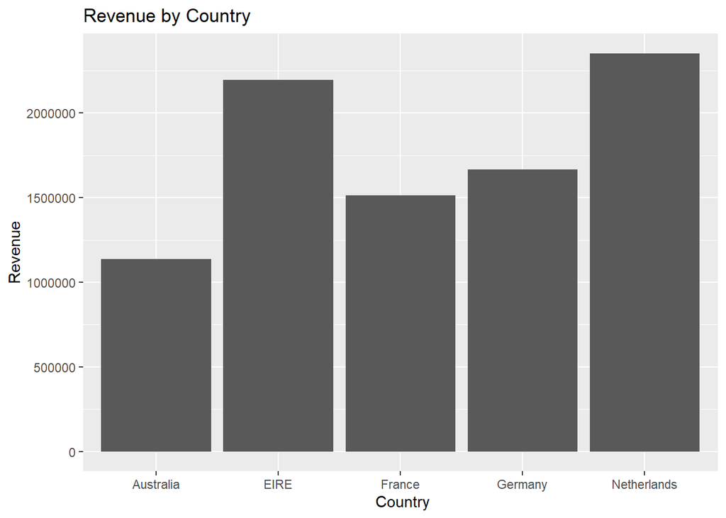

```r
ggplot(top_Country_Summary, aes(x = Country, y = revenue), colour = Country) + geom_col() + labs(x = ' Country', y = 'Revenue', title = 'Revenue by Country')
```

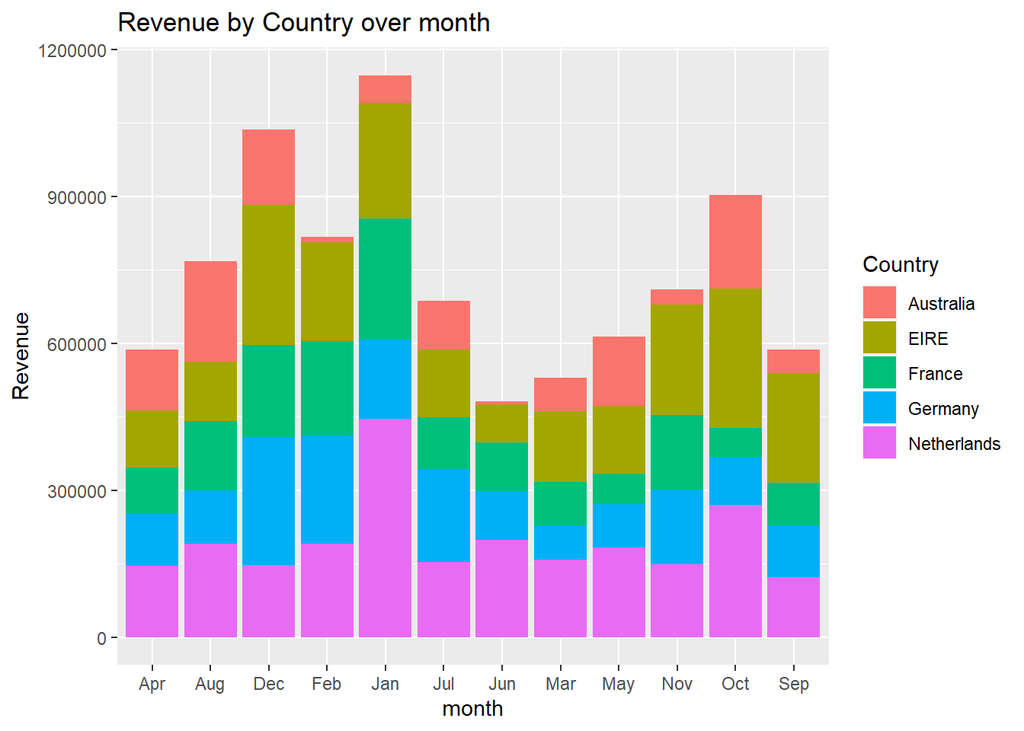

```r
ggplot(top_Country_Summary, aes(x = month, y = revenue,fill = Country))+geom_col()+ labs(x = 'month', y = 'Revenue', title = 'Revenue by Country over month')
```

Thus they were on top in the list of ‘revenue by country’.

```r
orders_per_day<-data%>%group_by(day)%>%summarise(Number_of_Orders=n())%>%mutate(Percentage_of_orders=(Number_of_Orders*100/nrow(data)))
```

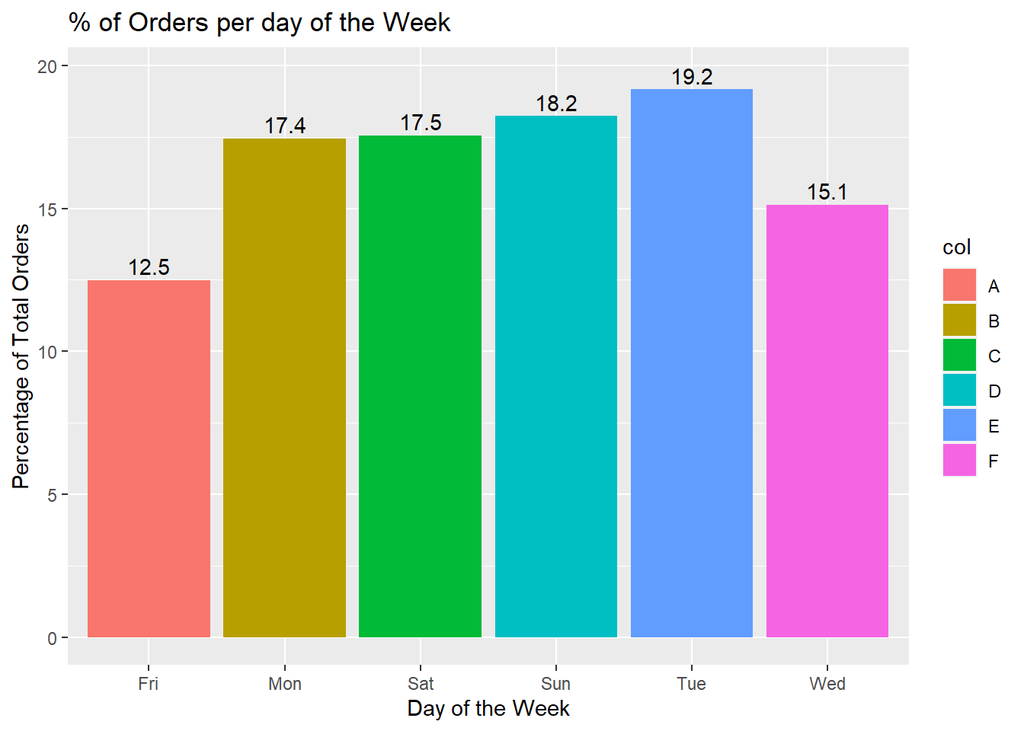

```r
#Visualizing Number of Orders per day of the week
col = c("A","B","C","D","E","F")
df = cbind(df,col)
ggplot(orders_per_day,aes(x=day,y=Percentage_of_orders,label=paste0(round(Percentage_of_orders,1)),fill = col))+
  geom_bar(stat = "identity")+labs(title="% of Orders per day of the Week",y="Percentage of Total Orders",x="Day of the Week")+
  geom_text(nudge_y = .5)
```

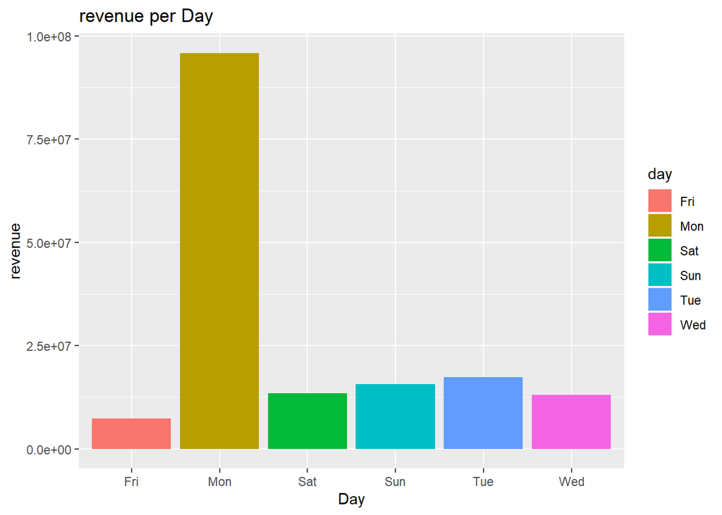

```r
#Visualizing revenue per day of the week
data %>%
  group_by(day) %>%
  summarise(revenue=sum(bill)) %>%
  ggplot(aes(x = day, y = revenue,fill = day)) + geom_col() + labs(x = 'Day', y = 'revenue', title = 'revenue per Day')
```

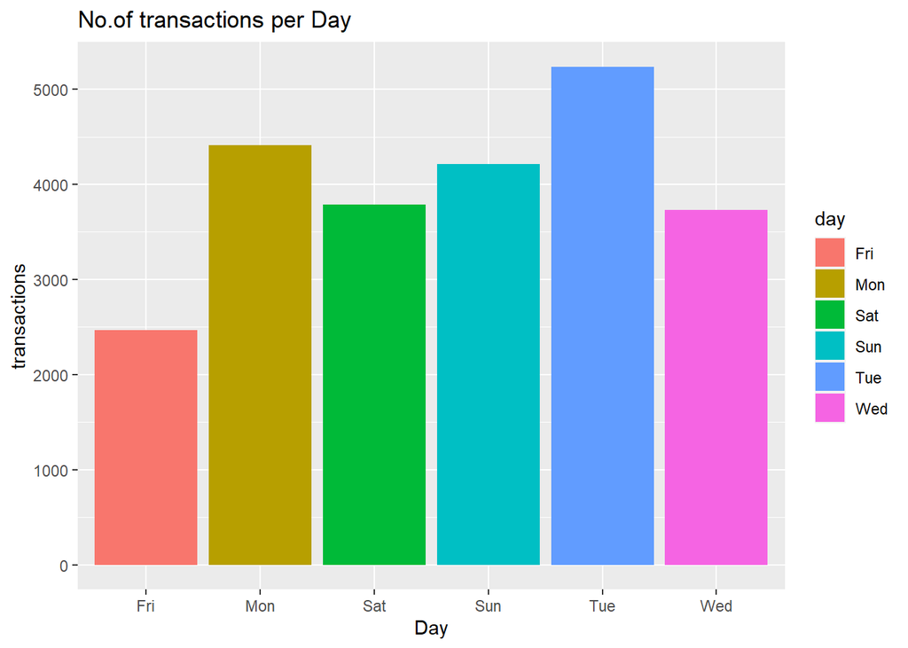

```r
#Visualizing No.of transactions per day of the week
data %>%
  group_by(day) %>%
  summarise(transactions=n_distinct(TransactionId)) %>%
  ggplot(aes(x = day, y = transactions,fill = day)) + geom_col() + labs(x = 'Day', y = 'transactions', title = 'No.of transactions per Day')
```

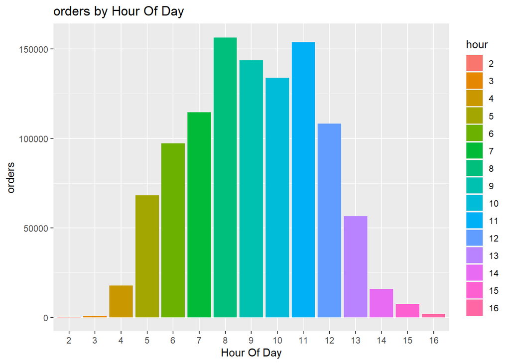

```r
#Visualizing Number of Orders per hour
data %>%
  group_by(hour) %>%
  summarise(Number_of_Orders=n()) %>%
  ggplot(aes(x = hour, y = Number_of_Orders,fill = hour)) + geom_col() + labs(x = 'Hour Of Day', y = 'orders', title = 'orders by Hour Of Day')
```

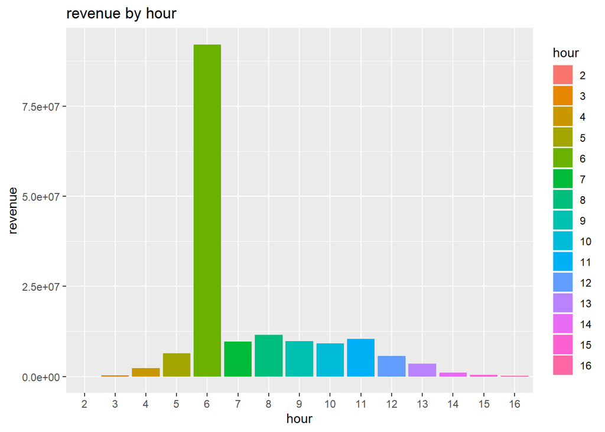

```r
#Visualizing revenue by hour
data %>%
  group_by(hour) %>%
  summarise(revenue=sum(bill)) %>%
  ggplot(aes(x = hour, y = revenue,fill = hour)) + geom_col() + labs(x = 'hour', y = 'revenue', title = 'revenue by hour')
```

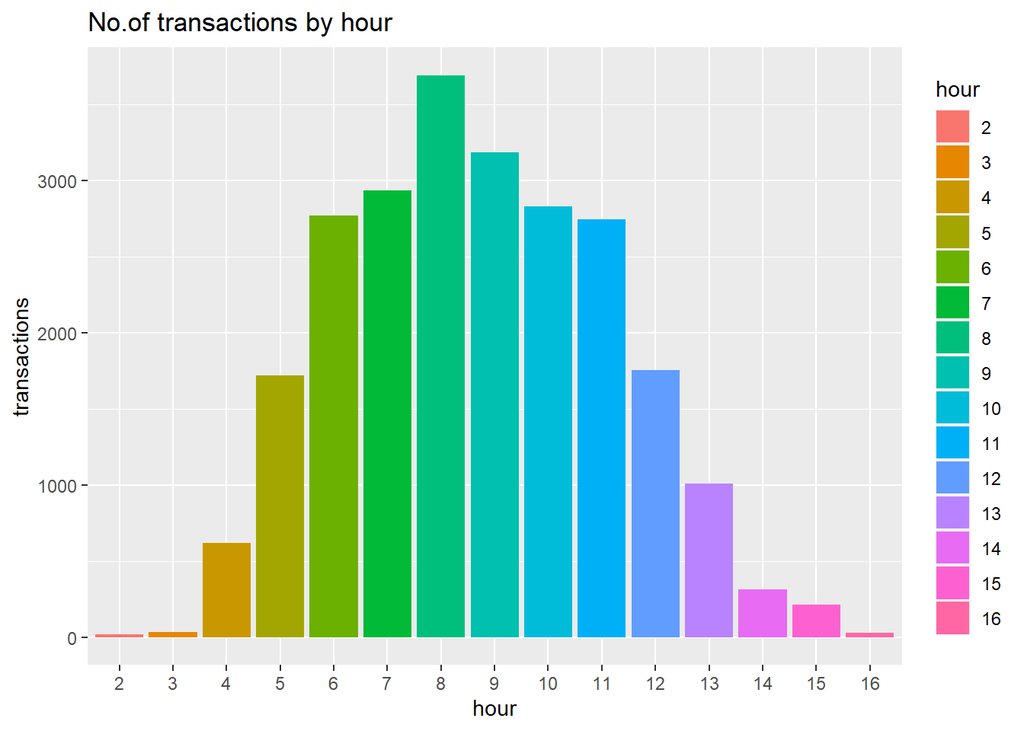

```r
#Visualizing Number of transactions by hour
data %>%
  group_by(hour) %>%
  summarise(transactions=n_distinct(TransactionId)) %>%
  ggplot(aes(x = hour, y = transactions,fill = hour)) + geom_col() + labs(x = 'hour', y = 'transactions', title = 'No.of transactions by hour')
```

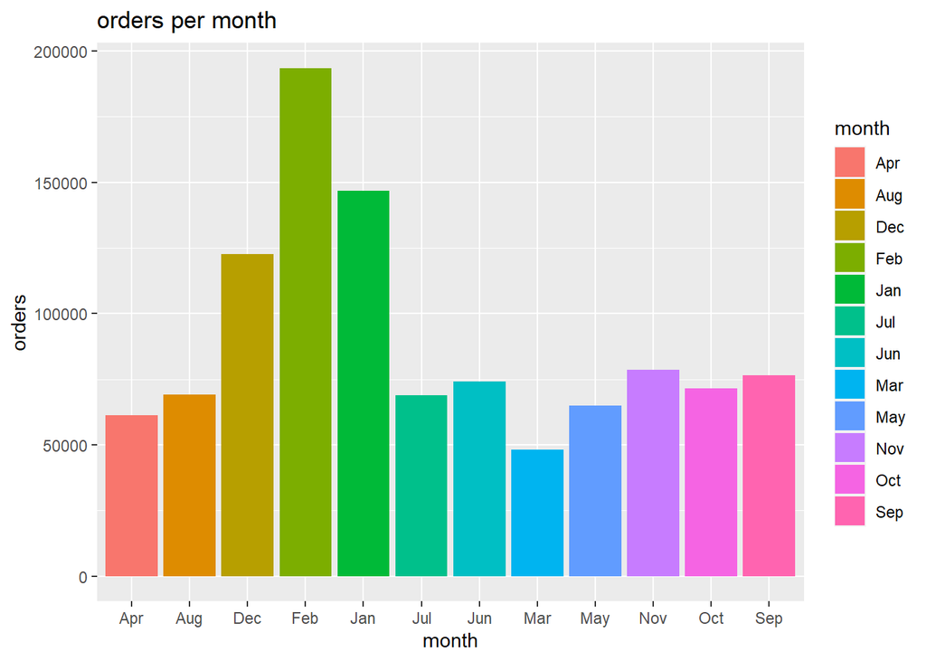

```r
#Visualizing Number of Orders per month
data %>%
  group_by(month) %>%
  summarise(Number_of_Orders=n()) %>%
  ggplot(aes(x = month, y = Number_of_Orders,fill = month)) + geom_col() + labs(x = 'month', y = 'orders', title = 'orders per month')
```

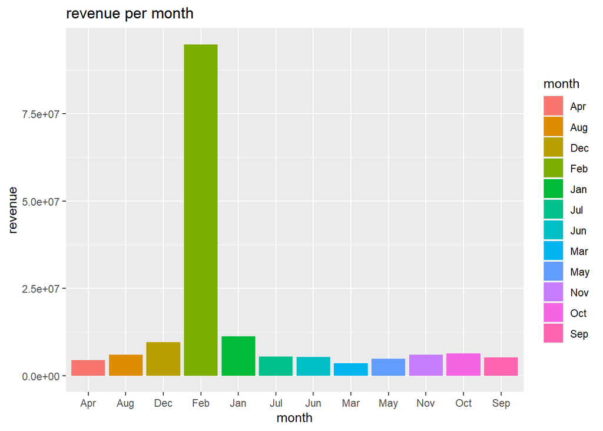

```r
#Visualizing revenue per month
data %>%
  group_by(month) %>%
  summarise(revenue=sum(bill)) %>%
  ggplot(aes(x = month, y = revenue,fill = month)) + geom_col() + labs(x = 'month', y = 'revenue', title = 'revenue per month')
```

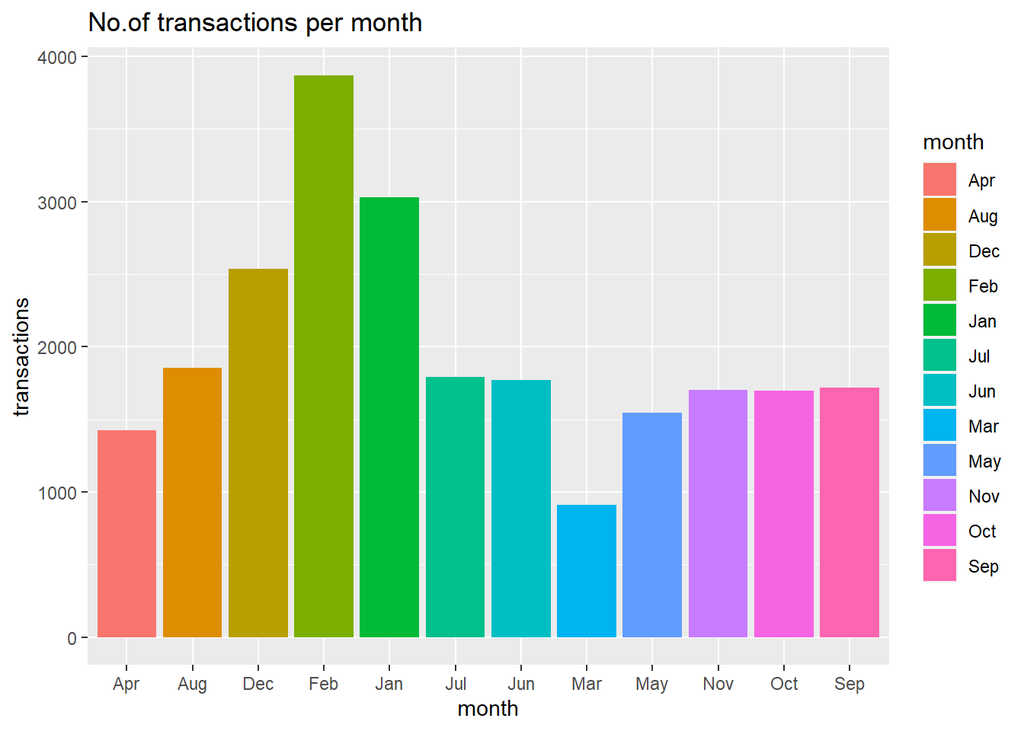

```r
#Visualizing No.of transactions per month
data %>%
  group_by(month) %>%
  summarise(transactions=n_distinct(TransactionId)) %>%
  ggplot(aes(x = month, y = transactions,fill = month)) + geom_col() + labs(x = 'month', y = 'transactions', title = 'No.of transactions per month')
```

Thus so far we have performed some cleaning, Extracting some important features, and did some Exploratory data analysis (EDA), Visualisation.

Now we are going to analyse the market basket history to pridict the combo’s of the items with the help of Association Rules.

```r
# MARKET BASKET ANALYSIS (APRIORI ALGO)

transactions = split(data$ItemCode,data$TransactionId)
transactions = as(transactions,"transactions") # Creating the transactions object
transactions
```

```
## transactions in sparse format with
##  23854 transactions (rows) and
##  3320 items (columns)
```

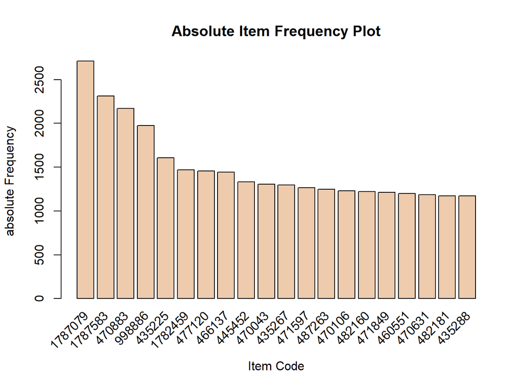

```r
itemFrequencyPlot(transactions, topN = 20, type="absolute", col="peachpuff2",xlab="Item Code",ylab="absolute Frequency", main="Absolute Item Frequency Plot")
```

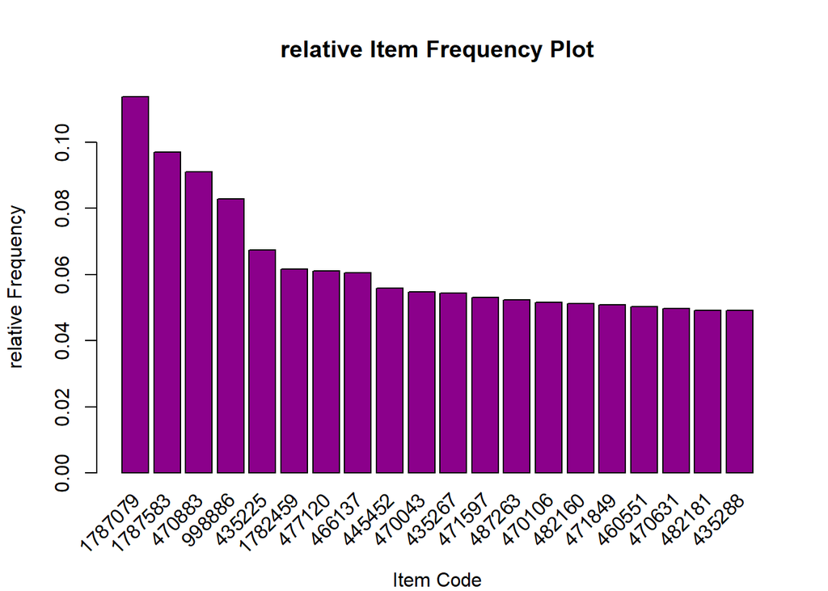

```r
itemFrequencyPlot(transactions, topN=20, type="relative", col="DarkMagenta",xlab="Item Code",ylab="relative Frequency", main="relative Item Frequency Plot")
```

```r
cat("These were the items bought per transaction\n\n")
```

```
## These were the items bought per transaction
```

```r
inspect(transactions[1:3])
```

```
##     items     transactionID
## [1] {456330,
##      477792,
##      1492113,
##      1764609,
##      1772526,
##      1787583}       5900015
## [2] {475272,
##      475293}        5900026
## [3] {456834,
##      456855,
##      457317,
##      468510,
##      475062,
##      475083,
##      477645,
##      477708,
##      477729,
##      1011927,
##      1782459,
##      1784349}       5900037
```

Now let us extract the good support values which increases the confidence and lift.

```r
# Support and confidence values
support_Levels <- c(0.05, 0.02, 0.003, 0.001)
confidence_Levels <- c(0.9, 0.8, 0.7, 0.6, 0.5, 0.4, 0.3, 0.2, 0.1)

# Empty integers
rules_sup5 <- integer(length=9)
rules_sup2 <- integer(length=9)
rules_sup0.3 <- integer(length=9)
rules_sup0.1 <- integer(length=9)

# Apriori algorithm with a support level of 5%
for (i in 1:length(confidence_Levels)) {

  rules_sup5[i] <- length(apriori(transactions, parameter=list(sup=support_Levels[1],
                                   conf=confidence_Levels[i],minlen = 3,maxlen = 3,
                                   target="rules")))

}
```

[output not shown]

[output cut: 134 more lines]

[output not shown]

```r
# Apriori algorithm with a support level of 2%
for (i in 1:length(confidence_Levels)){

  rules_sup2[i] <- length(apriori(transactions, parameter=list(sup=support_Levels[2],
                                  conf=confidence_Levels[i],minlen = 3,maxlen = 3,
                                  target="rules")))
}
```

[output not shown]

[output not shown]

[output not shown]

[output not shown]

[output not shown]

[output not shown]

[output not shown]

[output not shown]

[output not shown]

```
##  done [0.01s].
## writing ... [3 rule(s)] done [0.00s].
## creating S4 object  ... done [0.00s].
```

```r
# Apriori algorithm with a support level of 0.3%
for (i in 1:length(confidence_Levels)){

  rules_sup0.3[i] <- length(apriori(transactions, parameter=list(sup=support_Levels[3],
                                  conf=confidence_Levels[i],minlen = 3,maxlen = 3,
                                  target="rules")))

}
```

[output not shown]

[output not shown]

[output not shown]

[output not shown]

[output not shown]

[output not shown]

[output not shown]

[output not shown]

[output not shown]

```
##  done [0.40s].
## writing ... [94763 rule(s)] done [0.01s].
## creating S4 object  ... done [0.04s].
```

```r
# Apriori algorithm with a support level of 0.1%
for (i in 1:length(confidence_Levels)){

  rules_sup0.1[i] <- length(apriori(transactions, parameter=list(sup=support_Levels[4],
                                  conf=confidence_Levels[i],minlen = 3,maxlen = 3,
                                  target="rules")))

}
```

[output not shown]

[output not shown]

[output not shown]

[output not shown]

[output not shown]

[output not shown]

[output not shown]

[output not shown]

[output not shown]

```
##  done [3.93s].
## writing ... [11708025 rule(s)] done [1.82s].
## creating S4 object  ... done [2.79s].
```

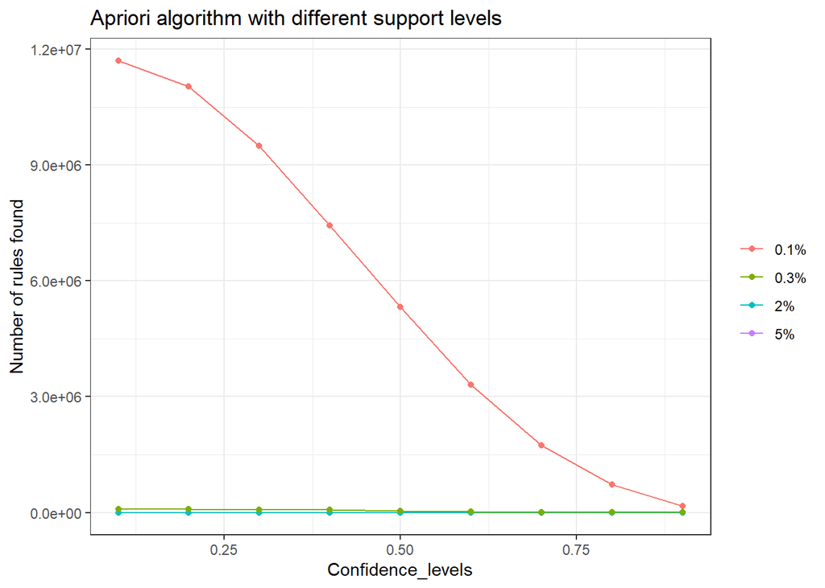

```r
# Data frame
num_rules <- data.frame(rules_sup5, rules_sup2, rules_sup0.3,rules_sup0.1, confidence_Levels)

# Number of rules found with a support level of 5%, 2%, 0.3% and 0.1%
ggplot(num_rules, aes(x=confidence_Levels)) +

  # Plot line and points (support level of 5%)
  geom_line(aes(y=rules_sup5, colour="5%")) +
  geom_point(aes(y=rules_sup5, colour="5%")) +

  # Plot line and points (support level of 2%)
  geom_line(aes(y=rules_sup2, colour="2%")) +
  geom_point(aes(y=rules_sup2, colour="2%")) +

  # Plot line and points (support level of 0.3%)
  geom_line(aes(y=rules_sup0.3, colour="0.3%")) +
  geom_point(aes(y=rules_sup0.3, colour="0.3%")) +

  # Plot line and points (support level of 0.1%)
  geom_line(aes(y=rules_sup0.1, colour="0.1%")) +
  geom_point(aes(y=rules_sup0.1, colour="0.1%")) +

  # Labs and theme
  labs(x="Confidence_levels", y="Number of rules found",
       title="Apriori algorithm with different support levels") +
  theme_bw() +
  theme(legend.title=element_blank())
```

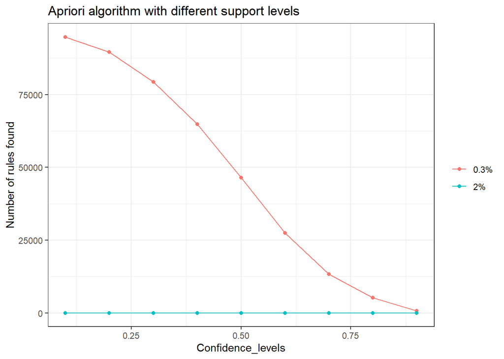

```r
ggplot(num_rules, aes(x=confidence_Levels)) +

  geom_line(aes(y=rules_sup0.3, colour="0.3%")) +
  geom_point(aes(y=rules_sup0.3, colour="0.3%"))+
  geom_line(aes(y=rules_sup2, colour="2%")) +
  geom_point(aes(y=rules_sup2, colour="2%"))+

  labs(x="Confidence_levels", y="Number of rules found",
       title="Apriori algorithm with different support levels") +
  theme_bw() +
  theme(legend.title=element_blank())
```

```r
summary(rules_sup0.3)
```

```
##    Min. 1st Qu.  Median    Mean 3rd Qu.    Max.
##     647   13327   46444   46833   79348   94763
```

```r
summary(rules_sup0.1)
```

```
##     Min.  1st Qu.   Median     Mean  3rd Qu.     Max.
##   167873  1732564  5321883  5658290  9495902 11708025
```

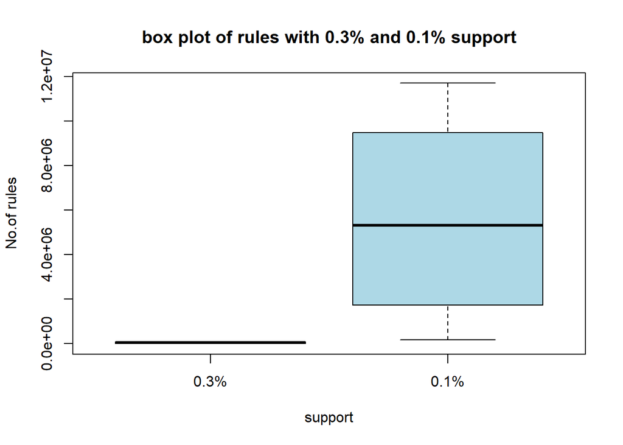

```r
boxplot(rules_sup0.3,rules_sup0.1,names = c("0.3%","0.1%"),col = c("red","light blue"), main = "box plot of rules with 0.3% and 0.1% support",xlab = "support",ylab = "No.of rules")
```

As we can see the support level of 0.3% has rules far much less than 0.1% and most of rules for 0.1% support will be undesirable with low support,confidence ans lift values.

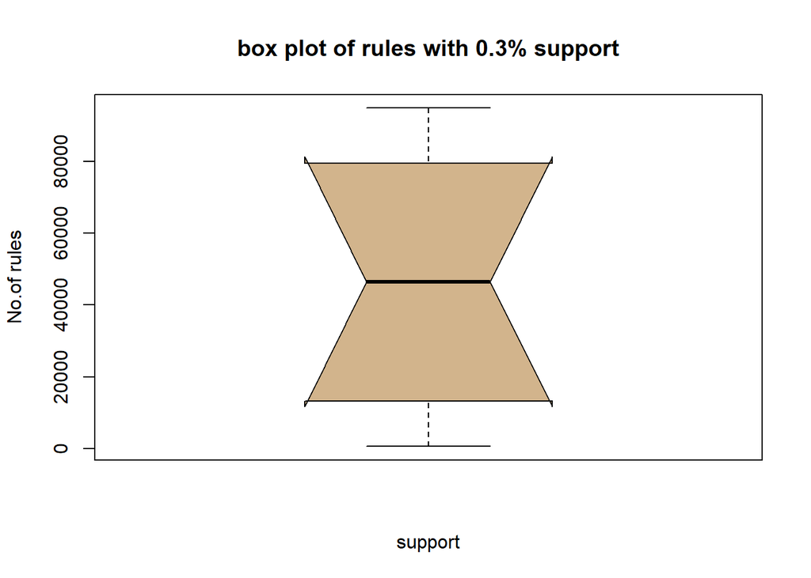

```r
boxplot(rules_sup0.3,names = c("0.3%"),col = c("tan"), main = "box plot of rules with 0.3% support",xlab = "support",ylab = "No.of rules",notch = T)
```

The 0.3% support also given large number of rules but in further process as we filter the rules with some conditions we will get desirable rules.

Thus support of 0.3% is best for further analysis

Thus it is best suitable for our prediction of 2 more items.

```r
rules <- apriori(transactions, parameter = list(supp = 0.003,minlen = 3,maxlen = 3))
```

```
## Apriori
##
## Parameter specification:
##  confidence minval smax arem  aval originalSupport maxtime support minlen
##         0.8    0.1    1 none FALSE            TRUE       5   0.003      3
##  maxlen target  ext
##       3  rules TRUE
##
## Algorithmic control:
##  filter tree heap memopt load sort verbose
##     0.1 TRUE TRUE  FALSE TRUE    2    TRUE
##
## Absolute minimum support count: 71
##
## set item appearances ...[0 item(s)] done [0.00s].
## set transactions ...[3320 item(s), 23854 transaction(s)] done [0.21s].
## sorting and recoding items ... [1832 item(s)] done [0.01s].
## creating transaction tree ... done [0.02s].
## checking subsets of size 1 2 3
```

```
##  done [0.41s].
## writing ... [5206 rule(s)] done [0.01s].
## creating S4 object  ... done [0.01s].
```

```r
summary(rules)
```

```
## set of 5206 rules
##
## rule length distribution (lhs + rhs):sizes
##    3
## 5206
##
##    Min. 1st Qu.  Median    Mean 3rd Qu.    Max.
##       3       3       3       3       3       3
##
## summary of quality measures:
##     support           confidence        coverage             lift
##  Min.   :0.003018   Min.   :0.8000   Min.   :0.003102   Min.   :  7.037
##  1st Qu.:0.003228   1st Qu.:0.8202   1st Qu.:0.003815   1st Qu.:  7.486
##  Median :0.003563   Median :0.8444   Median :0.004234   Median : 16.422
##  Mean   :0.004086   Mean   :0.8510   Mean   :0.004805   Mean   : 20.374
##  3rd Qu.:0.004360   3rd Qu.:0.8750   3rd Qu.:0.005156   3rd Qu.: 24.556
##  Max.   :0.023015   Max.   :1.0000   Max.   :0.026998   Max.   :125.454
##      count
##  Min.   : 72.00
##  1st Qu.: 77.00
##  Median : 85.00
##  Mean   : 97.46
##  3rd Qu.:104.00
##  Max.   :549.00
##
## mining info:
##          data ntransactions support confidence
##  transactions         23854   0.003        0.8
```

Thus from the confidence and the lift values we can accept these rules for predictions.

```
## To reduce overplotting, jitter is added! Use jitter = 0 to prevent jitter.
```

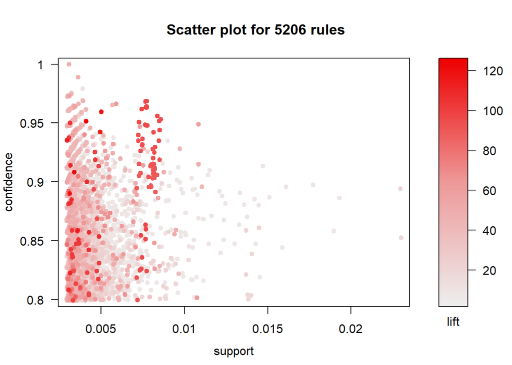

```r
plot(rules)
```

```r
rules_by_lift = sort(rules,by="lift")
write(rules_by_lift,"D:\\Internship\\rules_by_lift.txt", row.names = FALSE)
inspect(rules_by_lift[1:10])
```

```
##      lhs                 rhs      support     confidence coverage    lift
## [1]  {457821,457863}  => {457842} 0.004150247 0.9519231  0.004359856 125.4540
## [2]  {457821,1787079} => {457842} 0.003311814 0.9080460  0.003647187 119.6714
## [3]  {489090,489111}  => {489069} 0.004946759 0.9593496  0.005156368 117.3555
## [4]  {457821,461832}  => {457842} 0.003060283 0.8902439  0.003437579 117.3253
## [5]  {489069,489132}  => {489111} 0.004862916 0.9430894  0.005156368 113.6185
## [6]  {457863,461832}  => {457842} 0.003563344 0.8585859  0.004150247 113.1531
## [7]  {457842,461853}  => {457863} 0.003018362 0.9350649  0.003227970 112.0856
## [8]  {457842,466137}  => {457863} 0.003144127 0.9146341  0.003437579 109.6366
## [9]  {457863,1787751} => {457842} 0.003102205 0.8222222  0.003772952 108.3607
## [10] {457821,457842}  => {457863} 0.004150247 0.9000000  0.004611386 107.8824
##      count
## [1]   99
## [2]   79
## [3]  118
## [4]   73
## [5]  116
## [6]   85
## [7]   72
## [8]   75
## [9]   74
## [10]  99
```

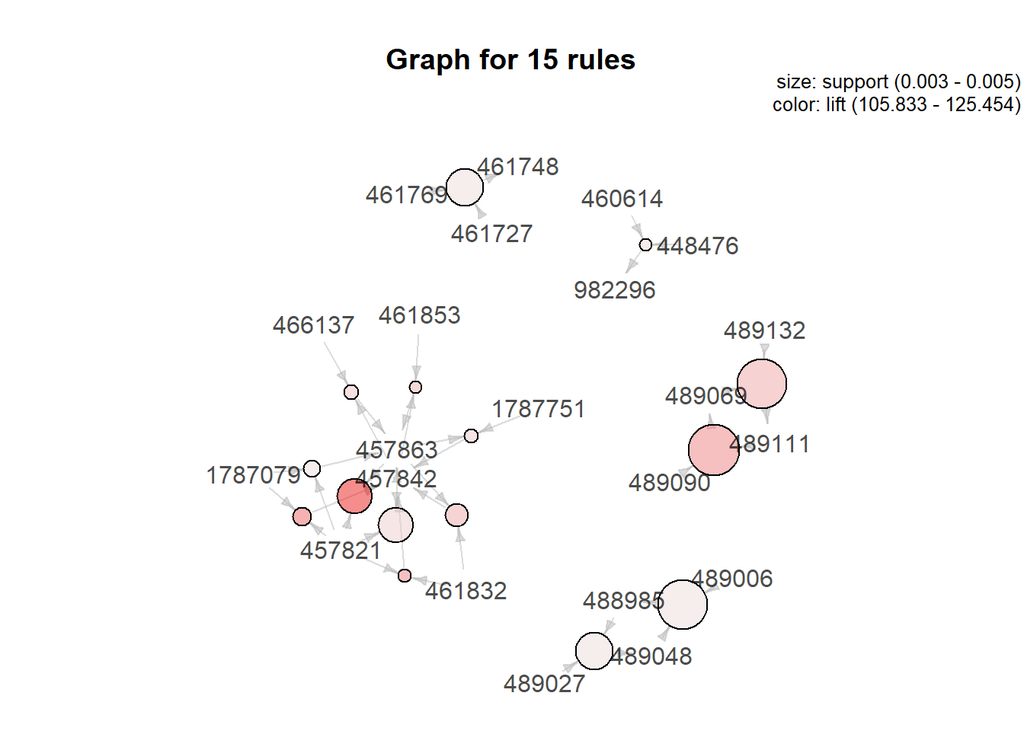

```r
plot(head(rules_by_lift,15),method="graph")
```

```r
rules_by_confidence = sort(rules,by="confidence")
write(rules_by_confidence,"D:\\Internship\\rules_by_confidence.txt", row.names = FALSE)
inspect(rules_by_lift[1:10])
```

```
##      lhs                 rhs      support     confidence coverage    lift
## [1]  {457821,457863}  => {457842} 0.004150247 0.9519231  0.004359856 125.4540
## [2]  {457821,1787079} => {457842} 0.003311814 0.9080460  0.003647187 119.6714
## [3]  {489090,489111}  => {489069} 0.004946759 0.9593496  0.005156368 117.3555
## [4]  {457821,461832}  => {457842} 0.003060283 0.8902439  0.003437579 117.3253
## [5]  {489069,489132}  => {489111} 0.004862916 0.9430894  0.005156368 113.6185
## [6]  {457863,461832}  => {457842} 0.003563344 0.8585859  0.004150247 113.1531
## [7]  {457842,461853}  => {457863} 0.003018362 0.9350649  0.003227970 112.0856
## [8]  {457842,466137}  => {457863} 0.003144127 0.9146341  0.003437579 109.6366
## [9]  {457863,1787751} => {457842} 0.003102205 0.8222222  0.003772952 108.3607
## [10] {457821,457842}  => {457863} 0.004150247 0.9000000  0.004611386 107.8824
##      count
## [1]   99
## [2]   79
## [3]  118
## [4]   73
## [5]  116
## [6]   85
## [7]   72
## [8]   75
## [9]   74
## [10]  99
```

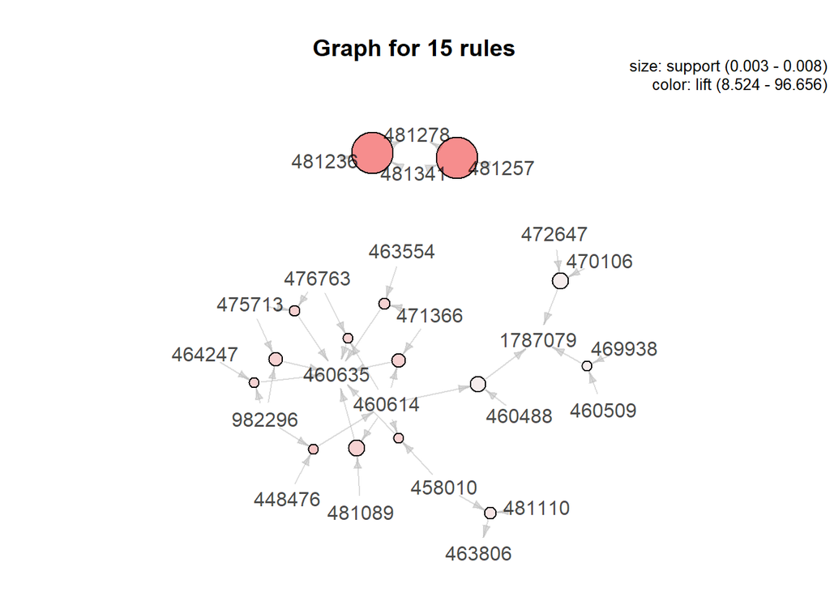

```r
plot(head(rules_by_confidence,15),method="graph")
```

The above graphs shows different set’s of items which will be purchased in combo with greater than 80% confidence.

We can also see the lift ranges from 7 to 125 which are sufficently large.

Therefore we can say that by placing these products side by side in store generates more revenue.